# Theory

Paper (2015): https://arxiv.org/pdf/1505.04597.pdf

**U-Net** is a network architecture used for semantic image segmentation. Originally was developed for medical data clustering, but applicable in all other settings.

The output of the newtork is 2 scores for each pixel of the image that predict 2 classes: Background / Object.

Model architecture looks like letter "U", that's why it got its name.

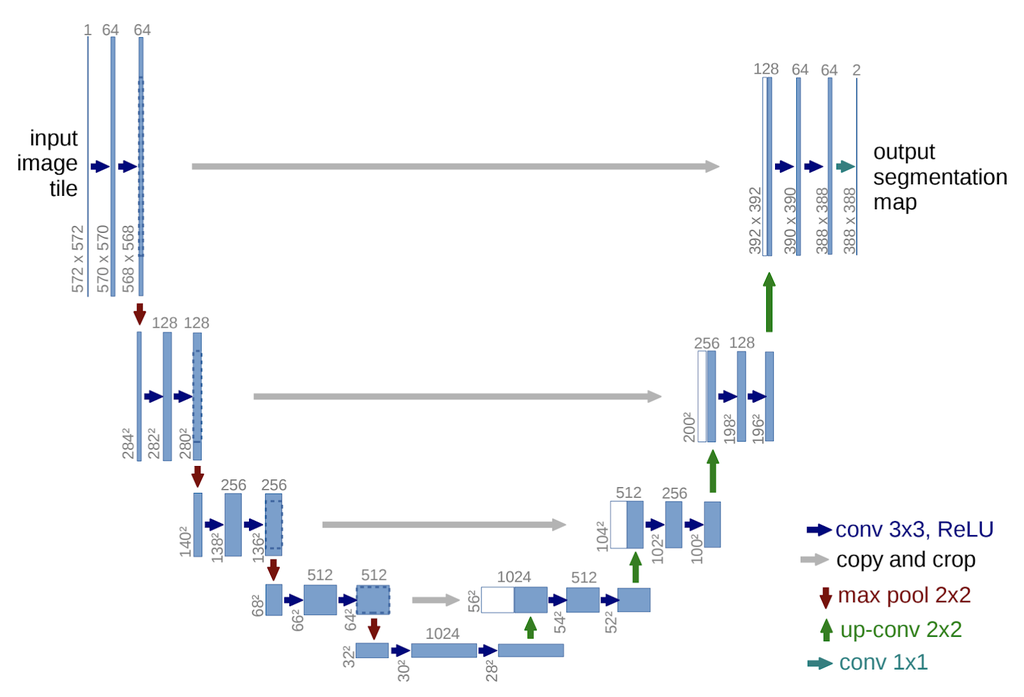

The network advances the **FPN** ([Fully Convolutional Network, 2014](https://arxiv.org/pdf/1411.4038.pdf)) architecture.

It shares FPNs main features:

- There is a **contracting** (or **downsampling**, or **encoder**) part that tries to model the semantics of the image
- There is an **expanding** (or **upsampling**, or **decoder**) part that tries to refine segmentation boundaries
- Encoder layers are directly connected to corresponding decoder layers and provide context for better boundary refinement

But there are couple of differences:

- the network has been made more symmetric, "expantion" part became a reflection of the "contraction" part

In general setting there could be more than 2 classes for semantic segmentation. In that case each pixel is assigned to either background class or one of N classes (cars / trees / pedestrians / houses)

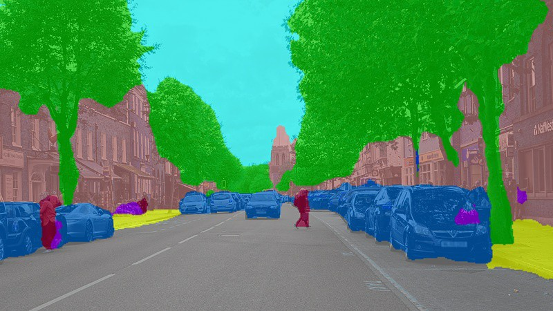

Applications of semantic image segmentation:

1. scene segmentation for self-driving cars
2. medical imaging
3. aerial photography / farming / geology

Datasets:

- Cityscapes
- https://www.kaggle.com/c/tgs-salt-identification-challenge/overview

References: https://nanonets.com/blog/semantic-image-segmentation-2020/

# Practice

Quick notes about implementation:

- All tensor operations in the network follow the same pattern thus they can be conveniently allocated in blocks
  - contraction blocks
  - intermediate layers
  - expansion blocks
- The authors opted to use no padding in covolutions (i.e. "valid" padding mode); To prevent unncessary cropping and make the task more simple padding can be safely changed to "same";

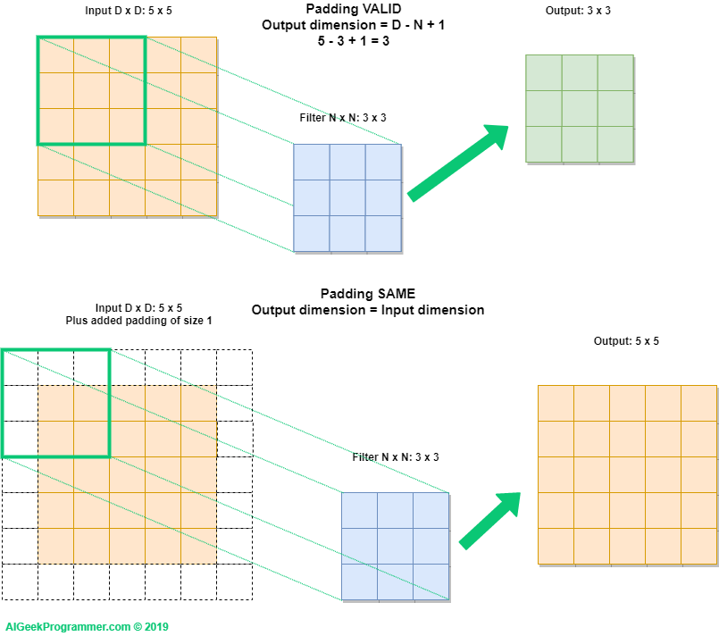

- Because of that, the output size of the network (388 x 388) is less than original (572 x 572) image size. To correctly process the whole image, the authors artificially enhance edges with mirrored data before processing (left);

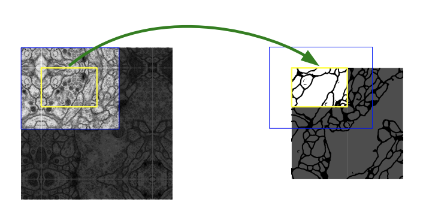

- In medical imaging, segments tend to stick to each other throughout a thin border. These boarders are hard to predict, so authors modified the loss function and gave more weight to such areas => weighted loss fucntion. This made the model make more effort on correctly classifying borders.
- Training on sparse data requires a lot of augmentation

## PyTorch

Let's define a paired convolution block - a sequence of 2 convolutions followed by ReLU activation

```python
import torch
import torch.nn as nn

def conv_block(in_channels, out_channels):
  return nn.Sequential(
      nn.Conv2d(in_channels, out_channels, kernel_size=3),
      nn.ReLU(inplace=True),
      nn.Conv2d(out_channels, out_channels, kernel_size=3),
      nn.ReLU(inplace=True)
  )
```

Now let's assemble the "encoder" part;

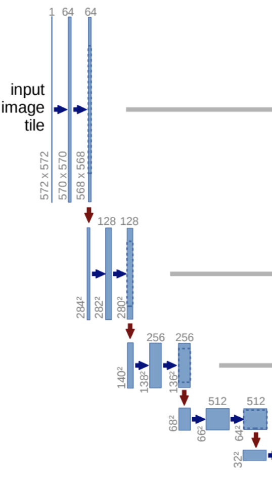

```python
class UNet(nn.Module):

    def __init__(self):
      super(UNet, self).__init__()

    def forward(self, image_tensor):

      # Encoder part

      x1 = conv_block(1,64)(image_tensor)
      x2 = nn.MaxPool2d(kernel_size=2, stride=2)(x1)

      x3 = conv_block(64,128)(x2)
      x4 = nn.MaxPool2d(kernel_size=2, stride=2)(x3)

      x5 = conv_block(128,256)(x4)
      x6 = nn.MaxPool2d(kernel_size=2, stride=2)(x5)

      x7 = conv_block(256,512)(x6)
      x8 = nn.MaxPool2d(kernel_size=2, stride=2)(x7)

      x9 = conv_block(512,1024)(x8)

      return x9
```

```python
input = torch.rand((1,1,572,572))
unet = UNet()
unet(input).shape
```

```
torch.Size([1, 1024, 28, 28])
```

#### Cropping

Since all convolutions are unpadded, they loose 2 pixels on each dimension. So in order to concatenate back during upconvolution, we'll have to crop a feature map from the encoder.

```python
def crop_features(encoder_features, decoder_features):
  edge_size = (encoder_features.shape[2] - decoder_features.shape[2]) // 2
  return encoder_features[:, :, edge_size : encoder_features.shape[2] - edge_size, edge_size : encoder_features.shape[3] - edge_size]
```

Define upsampling logic

```python
def upconv_block(decoder_image, encoder_image, in_channels, out_channels):

  # Upconvolve image features
  upconv = nn.ConvTranspose2d(in_channels,  out_channels, kernel_size=2, stride=2)
  decoder_image_upsampled = upconv(decoder_image)

  # print("upsampled to {}".format(decoder_image_upsampled.shape))
  # print("counterpart size = {}".format(encoder_image.shape))

  # Crop the encoder counterpart
  encoder_image_cropped = crop_features(encoder_image, decoder_image_upsampled)
  # print("after image crop = {}".format(encoder_image_cropped.shape))

  # Concatenate decoder and encoder images
  decoder_image_concatenated = torch.cat([encoder_image_cropped, decoder_image_upsampled], 1)

  # Convolve twice
  result = conv_block(in_channels, out_channels)(decoder_image_concatenated)

  return result
```

Now let's assemble the decoder part

```python
class UNet(nn.Module):

    def __init__(self):
      super(UNet, self).__init__()

    def forward(self, image_tensor):


      # Encoder part

      x1 = conv_block(1,64)(image_tensor)
      x2 = nn.MaxPool2d(kernel_size=2, stride=2)(x1)

      x3 = conv_block(64,128)(x2)
      x4 = nn.MaxPool2d(kernel_size=2, stride=2)(x3)

      x5 = conv_block(128,256)(x4)
      x6 = nn.MaxPool2d(kernel_size=2, stride=2)(x5)

      x7 = conv_block(256,512)(x6)
      x8 = nn.MaxPool2d(kernel_size=2, stride=2)(x7)

      x9 = conv_block(512,1024)(x8)


      # Decoder part

      x10 = upconv_block(x9,  x7, in_channels = 1024, out_channels = 512)
      x11 = upconv_block(x10, x5, in_channels = 512, out_channels = 256)
      x12 = upconv_block(x11, x3, in_channels = 256, out_channels = 128)
      x13 = upconv_block(x12, x1, in_channels = 128, out_channels = 64)

      return x13
```

```python
input = torch.rand((1,1,572,572))
unet = UNet()
unet(input).shape
```

```
torch.Size([1, 64, 388, 388])
```

Finally we need to define 1x1 convolution with 2 output chennels (background / object)

```python
class UNet(nn.Module):

    def __init__(self):
      super(UNet, self).__init__()


    def forward(self, image_tensor):


      # Encoder part

      x1 = conv_block(1,64)(image_tensor)
      x2 = nn.MaxPool2d(kernel_size=2, stride=2)(x1)

      x3 = conv_block(64,128)(x2)
      x4 = nn.MaxPool2d(kernel_size=2, stride=2)(x3)

      x5 = conv_block(128,256)(x4)
      x6 = nn.MaxPool2d(kernel_size=2, stride=2)(x5)

      x7 = conv_block(256,512)(x6)
      x8 = nn.MaxPool2d(kernel_size=2, stride=2)(x7)

      x9 = conv_block(512,1024)(x8)


      # Decoder part

      x10 = upconv_block(x9,  x7, in_channels = 1024, out_channels = 512)
      x11 = upconv_block(x10, x5, in_channels = 512, out_channels = 256)
      x12 = upconv_block(x11, x3, in_channels = 256, out_channels = 128)
      x13 = upconv_block(x12, x1, in_channels = 128, out_channels = 64)


      # Output layer

      x14 = nn.Conv2d(in_channels=64, out_channels=2, kernel_size = 1)(x13)

      return x14
```

```python
input = torch.rand((1,1,572,572))
unet = UNet()
unet(input).shape
```

```
torch.Size([1, 2, 388, 388])
```

### Training the network

Let's train on PASCAL VOC dataset. It's not big but it's available diredctly from PyTorch.

```python
import torchvision
voc_dataset = torchvision.datasets.VOCSegmentation(root = "/Users/Konstantin/Documents/voc/train", download = False)
voc_dataset[0]
```

```
(<PIL.Image.Image image mode=RGB size=500x281 at 0x631382090>,
 <PIL.PngImagePlugin.PngImageFile image mode=P size=500x281 at 0x631382D90>)
```

Data records consist of two pieces:

1. Image (RGB)
2. Image Mask - RGB picture of objects

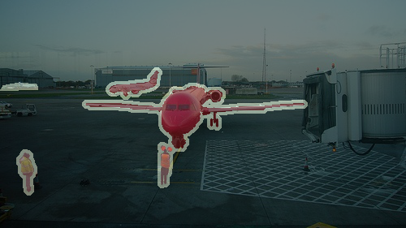

```python
import PIL
PIL.Image.blend(voc_dataset[0][0], voc_dataset[0][1].convert(mode='RGB'), alpha=0.5)
```

There are 20 classes in a dataset; Each class is represented with its own color;

```python
voc_targets = [
                [128, 0, 0],
                [0, 128, 0],
                [128, 128, 0],
                [0, 0, 128],
                [128, 0, 128],
                [0, 128, 128],
                [128, 128, 128],
                [64, 0, 0],
                [192, 0, 0],
                [64, 128, 0],
                [192, 128, 0],
                [64, 0, 128],
                [192, 0, 128],
                [64, 128, 128],
                [192, 128, 128],
                [0, 64, 0],
                [128, 64, 0],
                [0, 192, 0],
                [128, 192, 0],
                [0, 64, 128]
            ]

target_dict = {(x[0],x[1],x[2]):i for i,x in enumerate(voc_targets)}
```

```python
from tqdm.notebook import tqdm

def get_target(mask):
  img_mask = numpy.array(mask.getdata()).reshape(mask.width, mask.height, 3)
  target_tensor = torch.zeros(mask.width, mask.height, 3)
  for x in range(mask.width):
    for y in range(mask.height):
      pixel = (img_mask[x,y,0], img_mask[x,y,1], img_mask[x,y,2])
      if pixel == (0,0,0):
          continue
      target = target_dict[pixel] if pixel in target_dict else 0
      target_tensor[x,y,0] = 1
      target_tensor[x,y,1] = 1
      target_tensor[x,y,2] = 1
  return target_tensor

result = get_target(voc_dataset[0][1].convert(mode='RGB'))
```

```python
to_pil = torchvision.transforms.ToPILImage(mode='RGB')
to_tensot = torchvision.transforms.ToTensor()

mask = voc_dataset[0][1].convert(mode='RGB')

# to_pil(mask).apply_(lambda x: x+1)

# for i in mask.getdata():
#   res.append()
#   mask.putdata(new_list_of_pixels)
```

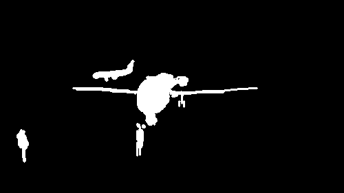

```python
for x in tqdm(range(mask.width)):
  for y in range(mask.height):
    mask.putpixel((x,y), (255,255,255) if mask.getpixel((x,y)) in target_dict else (0,0,0))
mask
```

Define training process

```python
model = UNet()
optimizer(model.parameters())
for epoch in range(10):
  for img,img_mask in voc_dataset:
  y_pred = model(img)
  y_true = get_target(img_mask)
  loss = crosscategory(y_true, y_pred)
  loss.backward()
```

## Keras

Let's do the same thing in Keras;

This time we will be using "SAME" padding mode

```python
from keras import Model
from keras.callbacks import EarlyStopping, ModelCheckpoint, ReduceLROnPlateau
from keras.optimizers import Adam
from keras.layers import Input, Conv2D, Conv2DTranspose, MaxPooling2D, concatenate, Dropout

def convolution_block(output_channels, input_tensor, dropout=False):
  conv1 = Conv2D(output_channels, (3, 3), activation="relu", padding="same")(input_tensor)
  conv2 = Conv2D(output_channels, (3, 3), activation="relu", padding="same")(conv1)
  return conv2

def convolution_pooling(input, dropout):
    pool = MaxPooling2D((2, 2))(input)
    if dropout:
        pool = Dropout(0.25)(pool)
    return pool

def deconvolution_block(output_channels, input, conv):
    deconv = Conv2DTranspose(output_channels, (3, 3), strides=(2, 2), padding="same")(input)
    uconv = concatenate([deconv, conv])
    uconv = Dropout(0.5)(uconv)
    uconv = Conv2D(output_channels, (3, 3), activation="relu", padding="same")(uconv)
    uconv = Conv2D(output_channels, (3, 3), activation="relu", padding="same")(uconv)
    return uconv

# Input
input_layer = Input((128, 128, 1))

# Contraction Part
conv1 = convolution_block(64, input_layer)
conv1_pooled = convolution_pooling(conv1, dropout=True)
conv2 = convolution_block(128, conv1_pooled)
conv2_pooled = convolution_pooling(conv2, dropout=True)
conv3 = convolution_block(256, conv2_pooled)
conv3_pooled = convolution_pooling(conv3, dropout=True)
conv4 = convolution_block(512, conv3_pooled)
conv4_pooled = convolution_pooling(conv4, dropout=True)

# Middle Part
convm = Conv2D(1024, (3, 3), activation="relu", padding="same")(conv4_pooled)
convm = Conv2D(1024, (3, 3), activation="relu", padding="same")(convm)

# Expansion Part
uconv4 = deconvolution_block(512, convm, conv4)
uconv3 = deconvolution_block(256, uconv4, conv3)
uconv2 = deconvolution_block(128, uconv3, conv2)
uconv1 = deconvolution_block(64, uconv2, conv1)

# Output
output_layer = Conv2D(1, (1,1), padding="same", activation="sigmoid")(uconv1)

model = Model(input_layer, output_layer)

model.compile(loss="binary_crossentropy", optimizer="adam", metrics=["accuracy"])
```

```python
model.summary()
```

```
Model: "model_1"
__________________________________________________________________________________________________
Layer (type)                    Output Shape         Param #     Connected to
==================================================================================================
input_9 (InputLayer)            (None, 128, 128, 1)  0
__________________________________________________________________________________________________
conv2d_52 (Conv2D)              (None, 128, 128, 64) 640         input_9[0][0]
__________________________________________________________________________________________________
conv2d_53 (Conv2D)              (None, 128, 128, 64) 36928       conv2d_52[0][0]
__________________________________________________________________________________________________
max_pooling2d_21 (MaxPooling2D) (None, 64, 64, 64)   0           conv2d_53[0][0]
__________________________________________________________________________________________________
dropout_22 (Dropout)            (None, 64, 64, 64)   0           max_pooling2d_21[0][0]
__________________________________________________________________________________________________
conv2d_54 (Conv2D)              (None, 64, 64, 128)  73856       dropout_22[0][0]
__________________________________________________________________________________________________
conv2d_55 (Conv2D)              (None, 64, 64, 128)  147584      conv2d_54[0][0]
__________________________________________________________________________________________________
max_pooling2d_22 (MaxPooling2D) (None, 32, 32, 128)  0           conv2d_55[0][0]
__________________________________________________________________________________________________
dropout_23 (Dropout)            (None, 32, 32, 128)  0           max_pooling2d_22[0][0]
__________________________________________________________________________________________________
conv2d_56 (Conv2D)              (None, 32, 32, 256)  295168      dropout_23[0][0]
__________________________________________________________________________________________________
conv2d_57 (Conv2D)              (None, 32, 32, 256)  590080      conv2d_56[0][0]
__________________________________________________________________________________________________
max_pooling2d_23 (MaxPooling2D) (None, 16, 16, 256)  0           conv2d_57[0][0]
__________________________________________________________________________________________________
dropout_24 (Dropout)            (None, 16, 16, 256)  0           max_pooling2d_23[0][0]
__________________________________________________________________________________________________
conv2d_58 (Conv2D)              (None, 16, 16, 512)  1180160     dropout_24[0][0]
__________________________________________________________________________________________________
conv2d_59 (Conv2D)              (None, 16, 16, 512)  2359808     conv2d_58[0][0]
__________________________________________________________________________________________________
max_pooling2d_24 (MaxPooling2D) (None, 8, 8, 512)    0           conv2d_59[0][0]
__________________________________________________________________________________________________
dropout_25 (Dropout)            (None, 8, 8, 512)    0           max_pooling2d_24[0][0]
__________________________________________________________________________________________________
conv2d_60 (Conv2D)              (None, 8, 8, 1024)   4719616     dropout_25[0][0]
__________________________________________________________________________________________________
```

[output cut: 37 more lines]

```
concatenate_7 (Concatenate)     (None, 128, 128, 128 0           conv2d_transpose_8[0][0]
                                                                 conv2d_53[0][0]
__________________________________________________________________________________________________
dropout_29 (Dropout)            (None, 128, 128, 128 0           concatenate_7[0][0]
__________________________________________________________________________________________________
conv2d_68 (Conv2D)              (None, 128, 128, 64) 73792       dropout_29[0][0]
__________________________________________________________________________________________________
conv2d_69 (Conv2D)              (None, 128, 128, 64) 36928       conv2d_68[0][0]
__________________________________________________________________________________________________
conv2d_70 (Conv2D)              (None, 128, 128, 1)  65          conv2d_69[0][0]
==================================================================================================
Total params: 34,512,193
Trainable params: 34,512,193
Non-trainable params: 0
__________________________________________________________________________________________________
```